# A Guide to Wine

# Introduction

In recent years, the amount of alcohol being had has increased, with minorities, women, and older adults drinking more than ever. Among the alcohols being readily consumed is wine - so much so that there are tropes about it in pop culture; memes about suburban wine moms are heavily referenced and brought up, and the idea of drinking wine is regarded as classy and proper. The amount of wine sales is high in the US and expected to grow, thanks to the millenial generation that is just coming of age. This tutorial will provide a data analysis of wines by examining point value ratings of wines, the countries of origin, the variety of wines, as well as provinces and the prices of the wines. This tutorial will also be investigating the null hypothesis of if there is a correlation between the point value rating and the price of wine. The first part of the tutorial will include, data collection, and tidying. The second part of the tutorial will be about data visualisation and analysis of the displayed data. The third section of the tutorial will demonstrate Exploratory Data Analysis (EDA), a linear regression model to process the analysis, and a hypothesis test to determine whether we should reject our null hypothesis or not.

# Required Libraries

In order to create this tutorial, including the graphs, and other visualisations, we need to include the following libraries:

The dataset being used for this tutorial can be found at https://www.kaggle.com/zynicide/wine-reviews/data

```r
library(tidyverse)
```

```r
library(ggplot2)
library(dplyr)
library(stringr)
library(tidyr)
```

# Part 1: Data Collection

In order to load the dataset, we first need to download it from https://www.kaggle.com/zynicide/wine-reviews/data. The dataset will be downloaded as a CSV (comma-separated value), as a file called winemag-data.first150k.csv . We then load our dataset into R using the following code:

```r
# loading code goes here
wine_csv <- read_csv("/Users/tara/Documents/UMD/Senior_Year/Spring2018/CMSC320/Projects/Final_Project/winemag-data_first150k.csv")

wine_csv
```

```
## # A tibble: 150,930 x 11
##       X1 country description    designation points price province region_1
##    <int> <chr>   <chr>          <chr>        <int> <dbl> <chr>    <chr>
##  1     0 US      This tremendo… Martha's V…     96 235   Califor… Napa Va…
##  2     1 Spain   Ripe aromas o… Carodorum …     96 110   Norther… Toro
##  3     2 US      Mac Watson ho… Special Se…     96  90.0 Califor… Knights…
##  4     3 US      This spent 20… Reserve         96  65.0 Oregon   Willame…
##  5     4 France  This is the t… La Brûlade      95  66.0 Provence Bandol
##  6     5 Spain   Deep, dense a… Numanthia       95  73.0 Norther… Toro
##  7     6 Spain   Slightly grit… San Román       95  65.0 Norther… Toro
##  8     7 Spain   Lush cedary b… Carodorum …     95 110   Norther… Toro
##  9     8 US      This re-named… Silice          95  65.0 Oregon   Chehale…
## 10     9 US      The producer … Gap's Crow…     95  60.0 Califor… Sonoma …
## # ... with 150,920 more rows, and 3 more variables: region_2 <chr>,
## #   variety <chr>, winery <chr>
```

## 1.1 Data Overview

The dataset contains the following attributes for each entity: country description designation points price province region_1 region_2 variety winery

## 1.2 Data Tidying

The dataset is already fairly tidy, as it is clear and concise, with uniform entries for most attributes per entity.

# Part 2: Data Analysis and Visualisation

### Price of Wine vs Point Value Rating

```r
# pipeline goes here
wine_pipe <- wine_csv %>%
  #filter(points > 90) %>%
  filter(!is.na(points)) %>%
  filter(!is.na(price)) %>%
  select(points, price) %>%
  group_by(points) %>%
  arrange(points)
wine_pipe
```

```
## # A tibble: 137,235 x 2
## # Groups:   points [21]
##    points price
##     <int> <dbl>
##  1     80 13.0
##  2     80  5.00
##  3     80 17.0
##  4     80 17.0
##  5     80  8.00
##  6     80 14.0
##  7     80 18.0
##  8     80 11.0
##  9     80 15.0
## 10     80 12.0
## # ... with 137,225 more rows
```

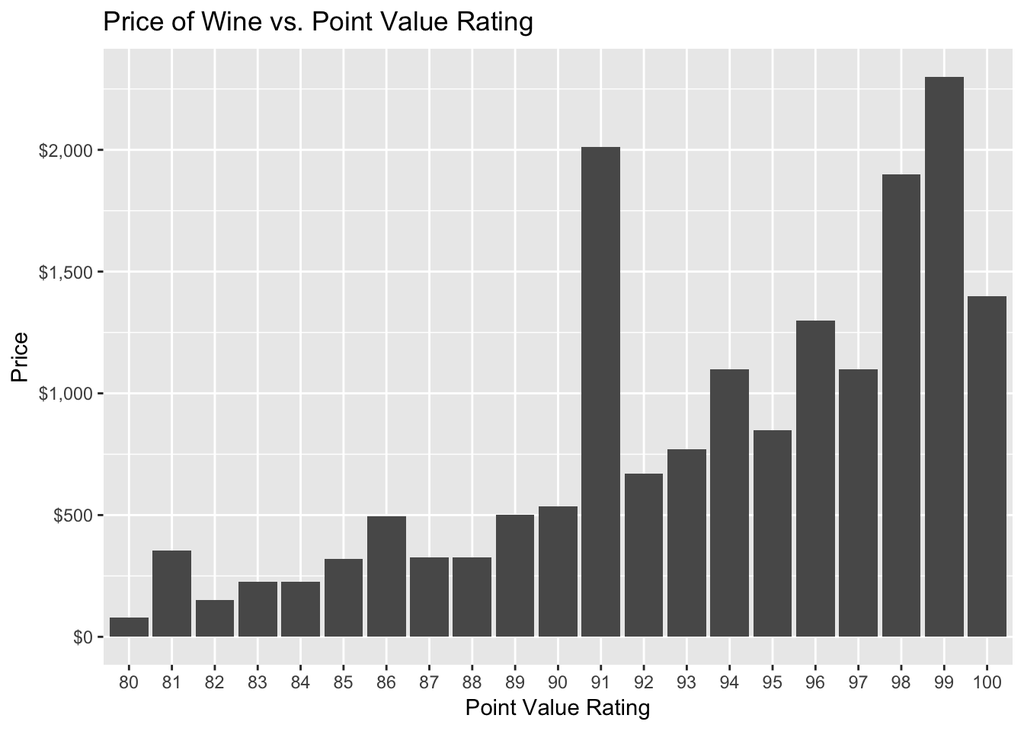

```r
# plot goes here
wine_pipe %>%
  ggplot(aes(x=factor(points), y=price)) +
  geom_bar(stat="identity",na.rm = TRUE, position = position_dodge())+
  scale_y_continuous(labels = scales::dollar) +
  ggtitle("Price of Wine vs. Point Value Rating") +
  labs(x = "Point Value Rating", y = "Price")
```

### Point Value Rating vs Production Region

```r
# pipeline goes here
wine_pipe2 <- wine_csv %>%
  filter(points > 90) %>%
  filter(price > 1000) %>%
  filter(!is.na(region_1)) %>%
  select(region_1, points) %>%
  group_by(points) %>%
  arrange(points)
wine_pipe2
```

```
## # A tibble: 9 x 2
## # Groups:   points [6]
##   region_1       points
##   <chr>           <int>
## 1 Arroyo Seco        91
## 2 Pauillac           96
## 3 Pessac-Léognan     96
## 4 Pessac-Léognan     97
## 5 Margaux            98
## 6 Pauillac           99
## 7 Champagne         100
## 8 Champagne         100
## 9 Champagne         100
```

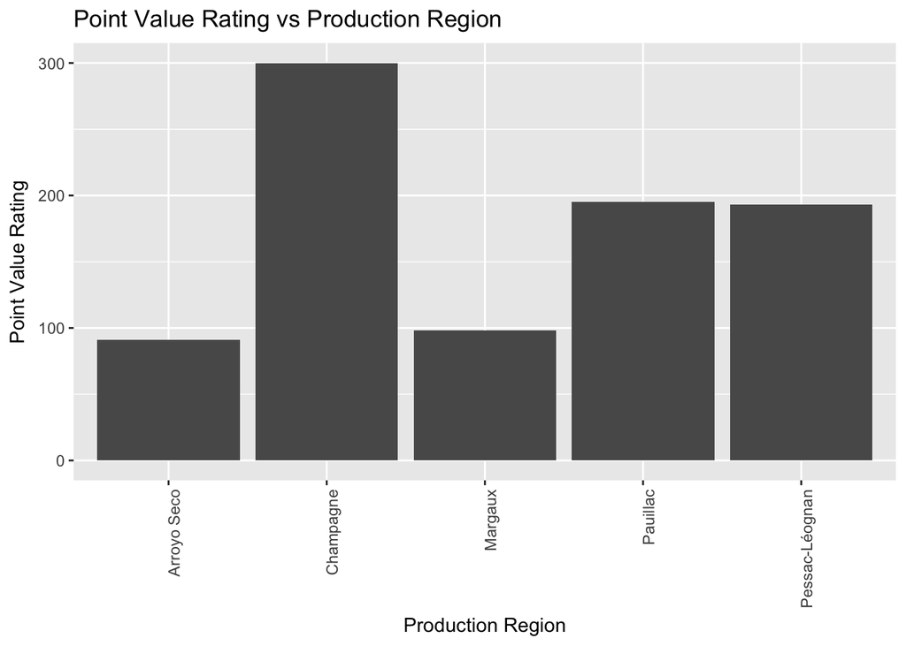

```r
# plot goes here
wine_pipe2 %>%
  ggplot(aes(x=region_1, y=points)) +
  geom_bar(stat="identity") +
  ggtitle("Point Value Rating vs Production Region")+
  labs(x="Production Region", y="Point Value Rating") +
  theme(axis.text.x = element_text(angle=90, hjust = 1))
```

### Country of Origin vs Variety of Wine

```r
# pipeline goes here
wine_pipe3 <- wine_csv %>%
  #filter(points > 90) %>%
  filter(price > 500) %>%
  filter(!is.na(country)) %>%
  select(variety, country) %>%
  group_by(variety) %>%
  arrange(variety)
wine_pipe3
```

```
## # A tibble: 73 x 2
## # Groups:   variety [18]
##    variety                  country
##    <chr>                    <chr>
##  1 Bordeaux-style Red Blend France
##  2 Bordeaux-style Red Blend France
##  3 Bordeaux-style Red Blend France
##  4 Bordeaux-style Red Blend France
##  5 Bordeaux-style Red Blend France
##  6 Bordeaux-style Red Blend France
##  7 Bordeaux-style Red Blend France
##  8 Bordeaux-style Red Blend France
##  9 Bordeaux-style Red Blend France
## 10 Bordeaux-style Red Blend France
## # ... with 63 more rows
```

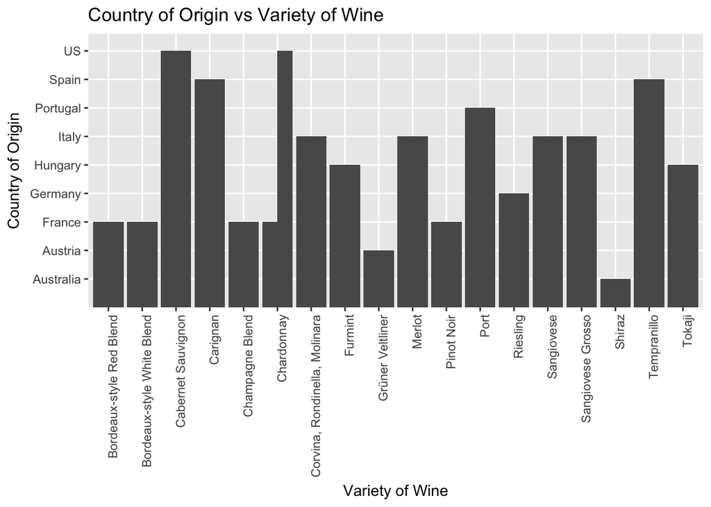

```r
# plot goes here
wine_pipe3 %>%
  ggplot(aes(x=variety, y=country)) +
  geom_bar(stat="identity",na.rm = TRUE, position = position_dodge()) +
  ggtitle("Country of Origin vs Variety of Wine")+
  labs(x = "Variety of Wine", y = "Country of Origin") +
  theme(axis.text.x = element_text(angle=90, hjust = 1))
```

### Point Value Rating vs Country of Origin

```r
# pipeline goes here
wine_pipe4 <- wine_csv %>%
  #filter(points > 90) %>%
  #filter(price > 1000) %>%
  filter(!is.na(country)) %>%
  select(points, country) %>%
  group_by(country) %>%
  arrange(country)
wine_pipe4
```

```
## # A tibble: 150,925 x 2
## # Groups:   country [48]
##    points country
##     <int> <chr>
##  1     88 Albania
##  2     88 Albania
##  3     91 Argentina
##  4     91 Argentina
##  5     86 Argentina
##  6     86 Argentina
##  7     88 Argentina
##  8     87 Argentina
##  9     88 Argentina
## 10     94 Argentina
## # ... with 150,915 more rows
```

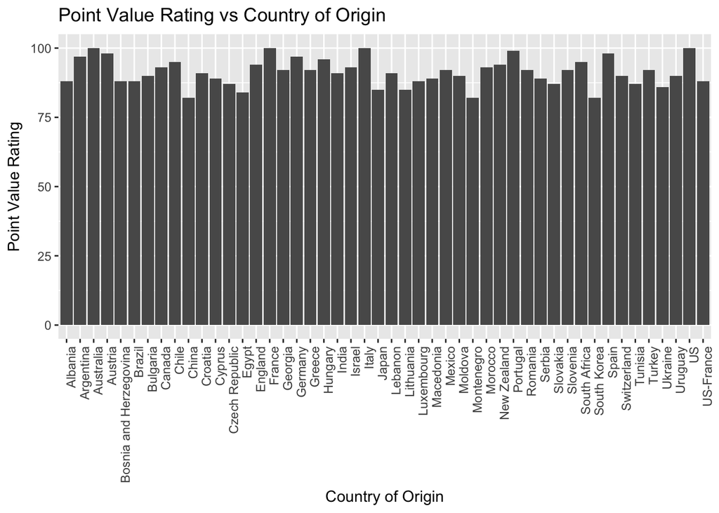

```r
# plot goes here
wine_pipe4 %>%
  ggplot(aes(x=country, y=points)) +
  geom_bar(stat="identity",na.rm = TRUE, position = position_dodge())+
  ggtitle("Point Value Rating vs Country of Origin") +
  labs(x = "Country of Origin", y = "Point Value Rating")+
  theme(axis.text.x = element_text(angle=90, hjust = 1))
```

This bar graph shows the Point Value Rating of wines by their Country of Origin. From this we can tell that the United States ranks fairly highly in terms of Point Value Rating, as does France, Italy, Australia, and Portugal among others.

### Price of Wine vs Country of Origin

```r
# pipeline goes here
wine_pipe5 <- wine_csv %>%
  #filter(points > 90) %>%
  filter(!is.na(country)) %>%
  select(country, price) %>%
  group_by(country) %>%
  arrange(country)
wine_pipe5
```

```
## # A tibble: 150,925 x 2
## # Groups:   country [48]
##    country   price
##    <chr>     <dbl>
##  1 Albania    20.0
##  2 Albania    20.0
##  3 Argentina  30.0
##  4 Argentina  25.0
##  5 Argentina  12.0
##  6 Argentina  15.0
##  7 Argentina  26.0
##  8 Argentina  15.0
##  9 Argentina  15.0
## 10 Argentina  50.0
## # ... with 150,915 more rows
```

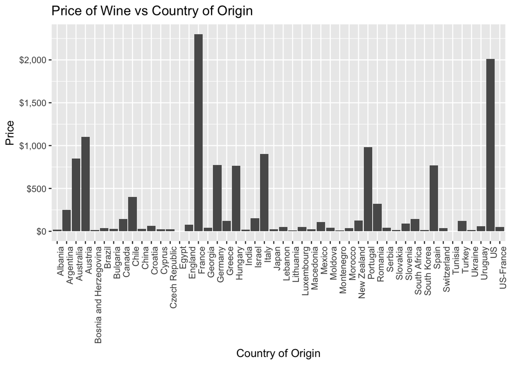

```r
# plot goes here
wine_pipe5 %>%
  ggplot(aes(x=country, y=price)) +
  geom_bar(stat="identity",na.rm = TRUE, position = position_dodge())+
  scale_y_continuous(labels = scales::dollar) +
  ggtitle("Price of Wine vs Country of Origin")+
  labs(x = "Country of Origin", y = "Price")+
  theme(axis.text.x = element_text(angle=90, hjust = 1))
```

# Part 3: Exploratory Data Analysis, Linear Regression and Hypothesis Testing

### Exploratory Data Analysis:

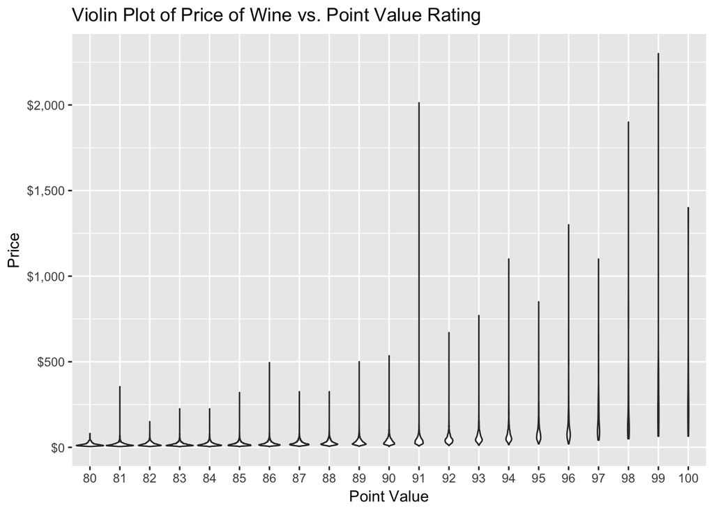

```r
# plot goes here
wine_pipe %>%
  ggplot(aes(x=factor(points), y=price)) +
  geom_violin()+
  scale_y_continuous(labels = scales::dollar) +
  ggtitle("Violin Plot of Price of Wine vs. Point Value Rating") +
  labs(x = "Point Value", y = "Price")
```

The plot above is a violin plot, showing the Price of Wine vs Point Value Rating. From this we can see that the majority of the data about the wines is being plotted very close to the x-axis, as that is where the body of the violin is widest.

### Linear Regression of Price of Wine vs Point Value Writing:

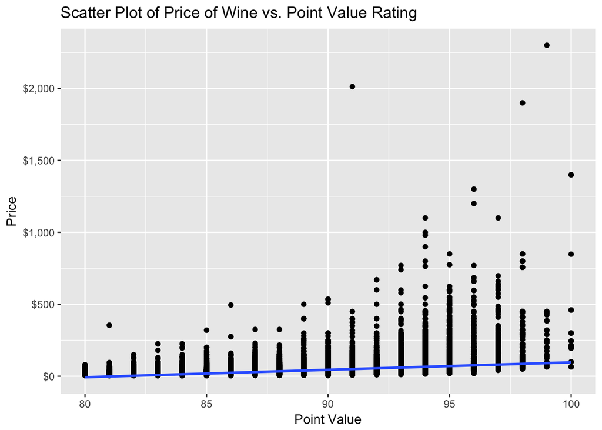

```r
# plot goes here
wine_pipe %>%
  ggplot(aes(x=points, y=price)) +
  geom_point()+
  geom_smooth(method="lm") +
  scale_y_continuous(labels = scales::dollar) +
  ggtitle("Scatter Plot of Price of Wine vs. Point Value Rating") +
  labs(x = "Point Value", y = "Price")
```

Doing a linear regression on a scatter plot of the same graph as above (Price of Wine vs Point Value Rating), we get the following blue line: it fits what we saw in the plot of the violin plots, that the trend says close to the x axis, going through where most of the point value ratings are plotted with respect to the price of the bottle of wine.

### Hypothesis Test:

Our null hypothesis is that there is no correlation between the price of wine and the point value it receives.

```r
#determine mean of points:
wine_csv %>% summarize( meanP = mean(points), na.rm = TRUE)
```

```
## # A tibble: 1 x 2
##   meanP na.rm
##   <dbl> <lgl>
## 1  87.9 T
```

```r
#determine standard deviation of points:
wine_csv %>% summarize(stdDevPoints = sd(points), na.rm = TRUE)
```

```
## # A tibble: 1 x 2
##   stdDevPoints na.rm
##          <dbl> <lgl>
## 1         3.22 T
```

```r
#hypothesis test
sample_df <- wine_csv %>% sample_n(100)
sample_df
```

```
## # A tibble: 100 x 11
##        X1 country  description  designation points price province region_1
##     <int> <chr>    <chr>        <chr>        <int> <dbl> <chr>    <chr>
##  1   4909 US       This blend … Rockin' One     90  49.0 Califor… Paso Ro…
##  2  82820 US       This wine's… <NA>            90  32.0 Califor… Santa L…
##  3  92121 US       Nicely dry … San Saba V…     85  23.0 Califor… Monterey
##  4  15789 Austria  This is rou… Guttenberg      89  NA   Burgenl… <NA>
##  5 134145 US       Cool climat… <NA>            86  11.0 Califor… Mendoci…
##  6   4931 Italy    Bright berr… Bacco in T…     87  18.0 Tuscany  Toscana
##  7  15518 Spain    Sweet on th… La Calera …     89  27.0 Norther… Toro
##  8  55360 Austral… This wine d… French Oak      86  17.0 New Sou… Hunter …
##  9 100141 US       Tart and ch… Red Wine        86  22.0 Washing… Washing…
## 10  75804 France   Dark in col… <NA>            89  25.0 Bordeaux Haut-Mé…
## # ... with 90 more rows, and 3 more variables: region_2 <chr>,
## #   variety <chr>, winery <chr>
```

```r
pnorm(mean(sample_df$points), mean(wine_csv$points), sd(sample_df$points), lower.tail = FALSE)
```

```
## [1] 0.5010204
```

# Conclusion

This tutorial displays how wines are priced according to a point value rating, and which countries and provinces good wines tend to come from. Hopefully this tutorial and more advanced statistics can be used to more deeply analyse consumer habits to stay ahead of the curve and the latest trend.

Thank you for reading this tutorial and hopefully you’ve gained more knowledge about data science, data visualisation, and data analysis in addition to learning about wine.

# References

https://www.npr.org/sections/thetwo-way/2017/08/10/542409957/drinking-on-the-rise-in-u-s-especially-for-women-minorities-older-adults http://www.decanter.com/wine-news/latest-wine-consumption-trends-356443-356443/ https://blogs.biomedcentral.com/bmcseriesblog/2017/06/12/micro-drinking-behaviors-responsible-increased-wine-consumption-served-larger-glass/ https://www.kaggle.com/zynicide/wine-reviews/data